▼ -0.85%

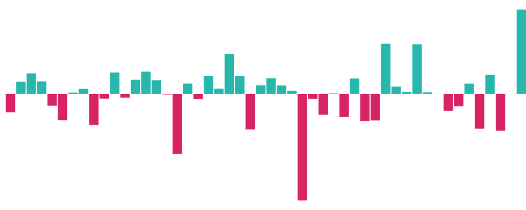

$44.36

$23.74

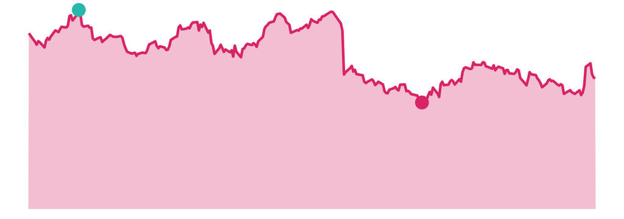

4.17M

▼ -19.92%

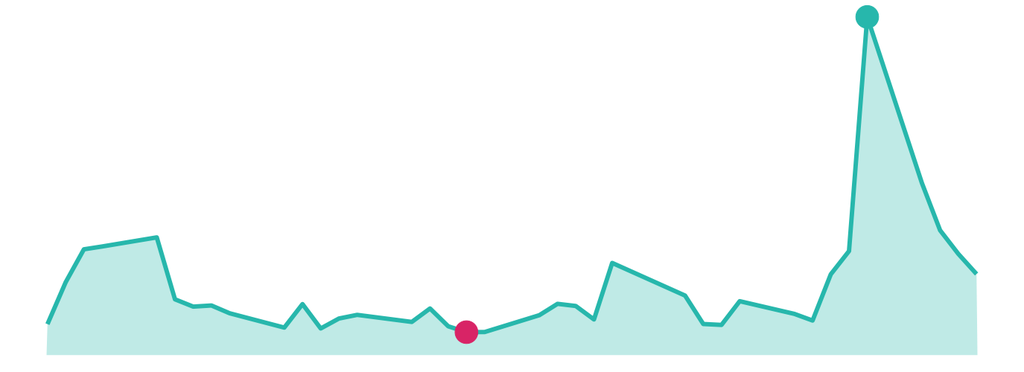

[figure not shown]

DYNATRACE, INC.

SYMBOL: DT

$46.57

▼ -1.00%

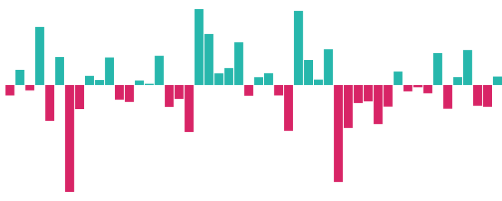

$60.70

$43.77

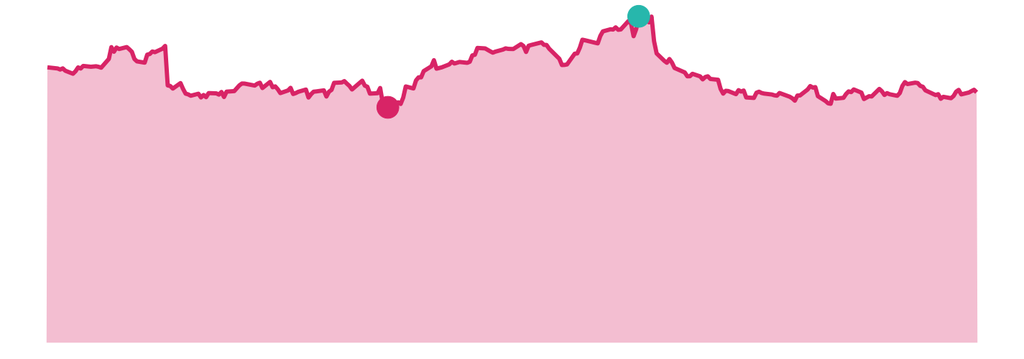

5.59M

▼ -28.84%

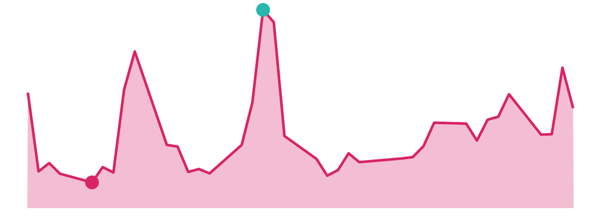

[figure not shown]

UIPATH, INC.

SYMBOL: PATH

$11.53

▼ -2.37%

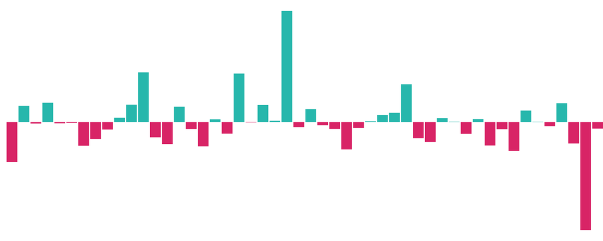

$26.88

$11.53

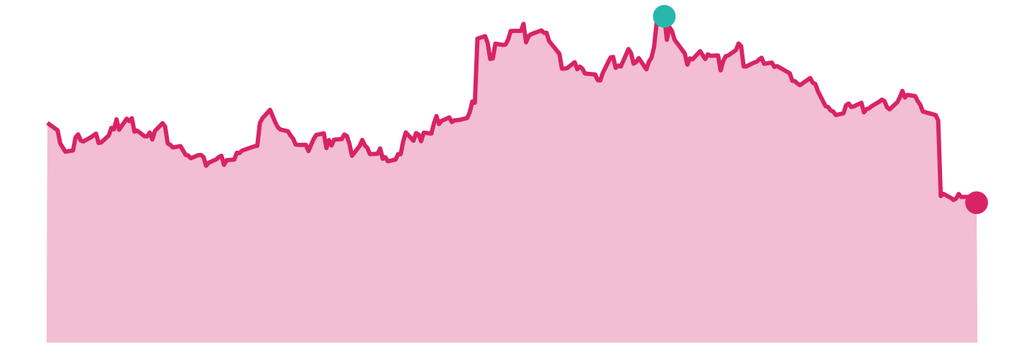

11.98M

▼ -16.63%

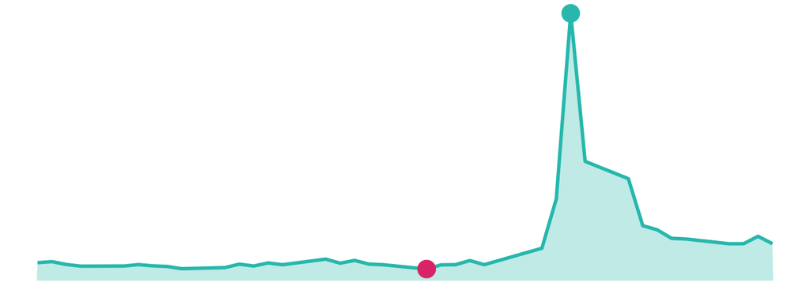

[figure not shown]

SENTINELONE, INC.

SYMBOL: S

$18.41

▲ 1.71%

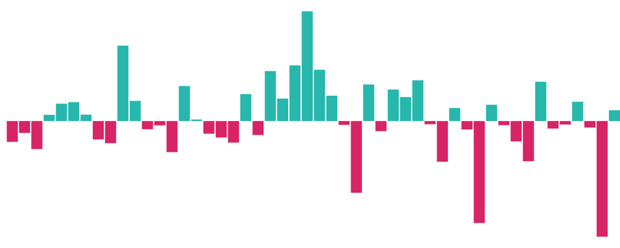

$30.00

$14.24

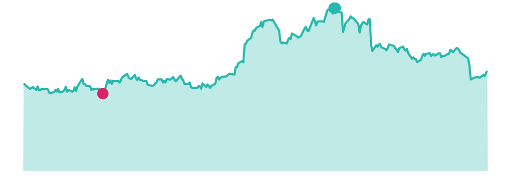

4.09M

▼ -27.61%

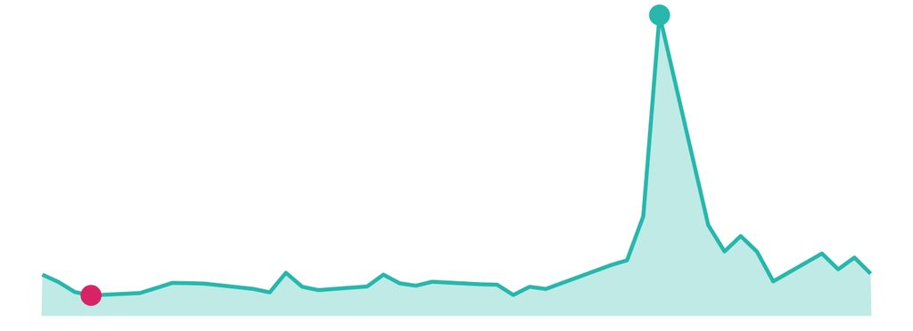

[figure not shown]

DARKTRACE PLC

SYMBOL: DARK.L

£579.00

▼ -0.92%

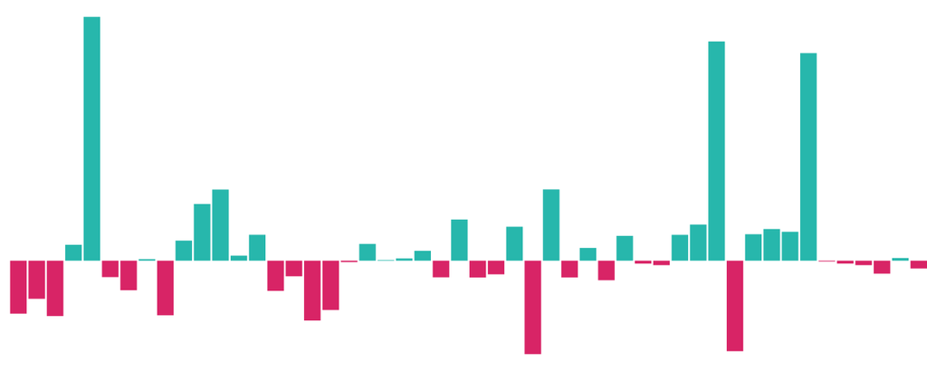

£603.40

£286.00

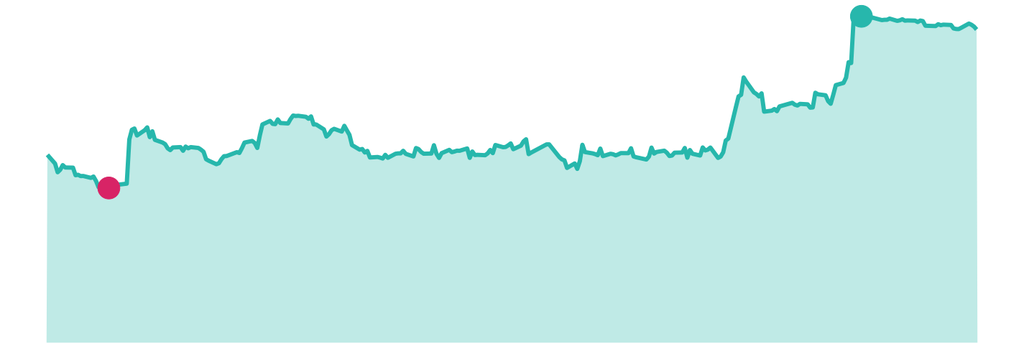

1.74M

▲ 121.98%

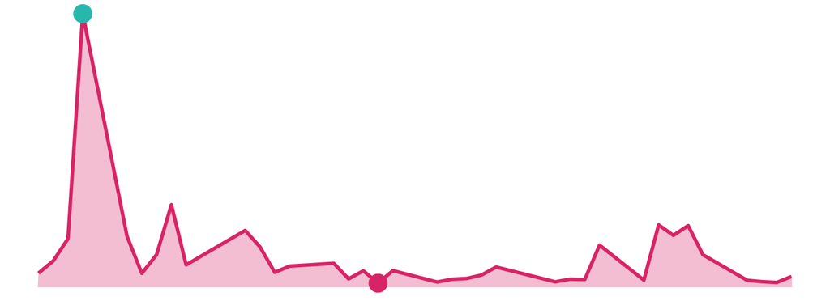

[figure not shown]

AURORA INNOVATION, INC.

SYMBOL: AUR

$2.50

▼ -1.19%

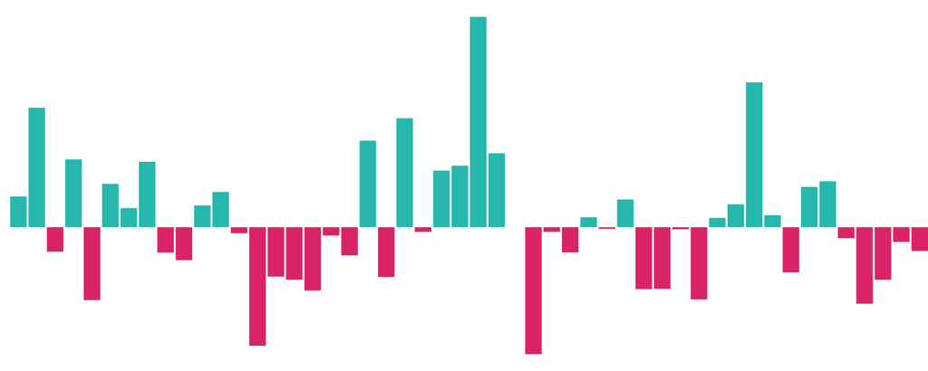

$4.69

$1.67

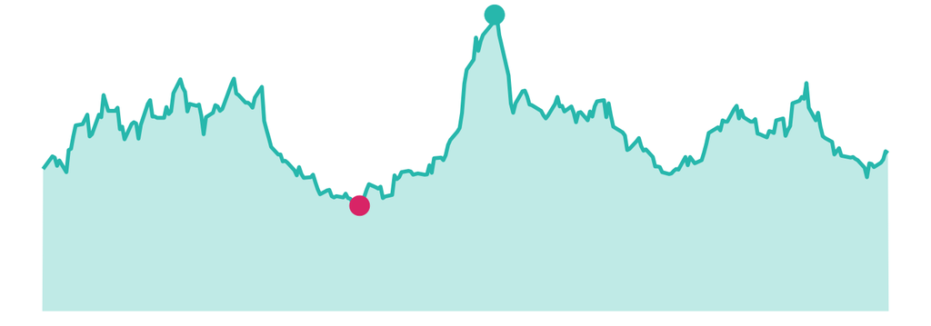

7.90M

▼ -38.58%

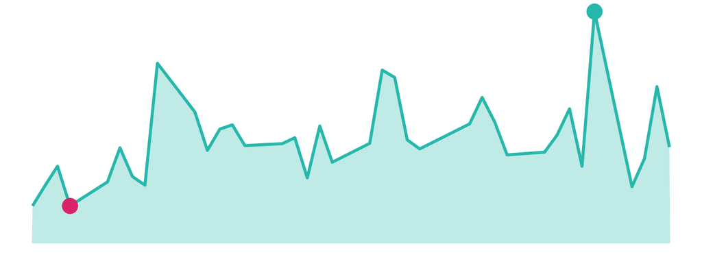

**Data Last Updated: June 13, 2024**